# Support Vector Machine en R

# 1. Introducción

- Vimos que la esencia de este método es encontrar un hiperplano separador
- Tal que los objetos queden separados según sus categorías
- Pero todo depende de si los datos son linealmente separables o no
- En cuyo caso la función de optimización cambia
- Afortunadamente, diversos paquetes en R hacen esto por nosotros
- Veremos una aplicación para análisis de texto
- Reconocimiento óptico de caracteres (OCR)
- Esto es clave para escanear documentos
- Necesitamos que la máquina identifique a partir de manuscritos o textos en físico cada letra y la digitalice
- Esto es difícil por los muchos estilos de letra a mano que hay
- Y las diversas fuentes de impresión
- La idea es convertir patrones de los pixeles en letras del alfabeto

# 2. Datos

- Al procesar un documento, el software OCR divide el papel en una matriz
- Cada entrada contiene un único glyph
- Un glyph es una letra, símbolo o número
- La idea es asignar a cada glyph un caracter
- Asumiremos que este proceso ya se llevó a cabo
- Es decir, ya tenemos los glyphs y sus características
- Por simplicidad, supondremos que el documento solo contiene caracteres alfabéticos en inglés
- Entonce queremos asginar a cada glyph una de las 26 letras de la A a la Z
- Usaremos los datos `letterdata.csv`
- Esta base contiene 20.000 ejemplos de letras de las A a Z
- Que varían en la manera en la que están escritas
- Y por ende en sus características visuales
- La siguiente imagen muestra la forma en la que se ven algunos de estos glyphs:

**Ejemplo de Glyphs a Clasificar**

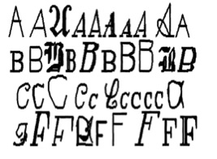

Fuente: Lantz (2015)

- Como puede verse, esto es fácil para el cerebro
- Pero seguramente muy difícil para un computador
- Exploremos los datos para entender su estrucura:

```r
letters <- read.csv("letterdata.csv")
```

```r
str(letters)
```

```
## 'data.frame':    20000 obs. of  17 variables:
##  $ letter: Factor w/ 26 levels "A","B","C","D",..: 20 9 4 14 7 19 2 1 10 13 ...
##  $ xbox  : int  2 5 4 7 2 4 4 1 2 11 ...
##  $ ybox  : int  8 12 11 11 1 11 2 1 2 15 ...
##  $ width : int  3 3 6 6 3 5 5 3 4 13 ...
##  $ height: int  5 7 8 6 1 8 4 2 4 9 ...
##  $ onpix : int  1 2 6 3 1 3 4 1 2 7 ...
##  $ xbar  : int  8 10 10 5 8 8 8 8 10 13 ...
##  $ ybar  : int  13 5 6 9 6 8 7 2 6 2 ...
##  $ x2bar : int  0 5 2 4 6 6 6 2 2 6 ...
##  $ y2bar : int  6 4 6 6 6 9 6 2 6 2 ...
##  $ xybar : int  6 13 10 4 6 5 7 8 12 12 ...
##  $ x2ybar: int  10 3 3 4 5 6 6 2 4 1 ...
##  $ xy2bar: int  8 9 7 10 9 6 6 8 8 9 ...
##  $ xedge : int  0 2 3 6 1 0 2 1 1 8 ...
##  $ xedgey: int  8 8 7 10 7 8 8 6 6 1 ...
##  $ yedge : int  0 4 3 2 5 9 7 2 1 1 ...
##  $ yedgex: int  8 10 9 8 10 7 10 7 7 8 ...
```

- Tenemos 20.000 ejemplos y 17 variables
- `letter` es la verdadera letra
- Las restantes 16 son características de los glyphs
- Por ejemplo las dimensiones horizontales y verticales, proporción de pixeles negros vs. blancos, posiciones horizontales y verticales promedio de los pixeles, etc.
- Las variables ya son numéricas, luego no tenemos que transformar factores
- Como algunos rango son muy grandes, es bueno estandarizar
- Pero el paquete que usaremos hace esto automáticamente

# 3. Entrenamiento del modelo

- La base ya fue limpiada en gran medida para nosotros
- Podemos correr los modelos inmediatamente
- Las letras ya fueron organizadas de manera aleatoria
- Luego, usaremos las primeras 16.000 observaciones para entrenar (el 80%)
- Y las restantes 4.000 para probarlo

```r
letters_train <- letters[1:16000, ]
letters_test <- letters[16001:20000, ]
```

- Hay diversos paquetes para hacer SVM en R
- Usaremos el paquete `kernlab`, que contiene la función `ksvm()`. Recuerden instalarlo con `install.packages("kernlab")`
- Y carguémoslo:

```r
library(kernlab)
```

- La sintaxis de la función `ksvm()`, para entrenar el modelo, es la siguiente: `m <- ksvm(target ~ predictors, data=mydata, kernel="rbfdot", C=1)`
- donde `target` es el outcome que queremos predecir
- `predictors` son las características usadas para predecir
- `data` es el data frame
- `kernel` especifica la función kernel a usar. El default es la gausiana RBF
- `C` es el costo de violar las restricciones
- Con esto, podemos entrenar nuestro modelo
- Usemos un kernel lineal

```r
letter_classifier <- ksvm(letter ~ ., data = letters_train, kernel="vanilladot")
```

- Podemos ver algunas características del objeto creado

```r
letter_classifier
```

```
## Support Vector Machine object of class "ksvm"
##
## SV type: C-svc  (classification)
##  parameter : cost C = 1
##
## Linear (vanilla) kernel function.
##
## Number of Support Vectors : 7037
##
## Objective Function Value : -14.1746 -20.0072 -23.5628 -6.2009 -7.5524 -32.7694 -49.9786 -18.1824 -62.1111 -32.7284 -16.2209 -32.2837 -28.9777 -51.2195 -13.276 -35.6217 -30.8612 -16.5256 -14.6811 -32.7475 -30.3219 -7.7956 -11.8138 -32.3463 -13.1262 -9.2692 -153.1654 -52.9678 -76.7744 -119.2067 -16…
## Training error : 0.130062
```

- No nos dice mucho

# 4. Desempeño del Modelo

- Debemos probar la precisión del modelo con la base de prueba
- La sintaxis para eso es `p <- predict(m, test, type=response)`
- donde `m` es el objeto creado en el entrenamiento
- `test` es la base de prueba
- `type` indica el tipo de predicción: `response` o `probabilities`. El default es `response`
- Así, nuestra predicción se hace de la siguiente forma

```r
letter_predictions <- predict(letter_classifier, letters_test)
```

- Se crea un vector indicando la letra predicha para cada uno de los 4.000 glyphs de prueba

```r
head(letter_predictions)
```

```
## [1] U N V X N H
## Levels: A B C D E F G H I J K L M N O P Q R S T U V W X Y Z
```

- Nos interesa ver qué tan preciso es el modelo
- Hagamos una tabla para comparar

```r
table(letter_predictions, letters_test$letter)
```

```
##
## letter_predictions   A   B   C   D   E   F   G   H   I   J   K   L   M   N
##                  A 144   0   0   0   0   0   0   0   0   1   0   0   1   2
##                  B   0 121   0   5   2   0   1   2   0   0   1   0   1   0
##                  C   0   0 120   0   4   0  10   2   2   0   1   3   0   0
##                  D   2   2   0 156   0   1   3  10   4   3   4   3   0   5
##                  E   0   0   5   0 127   3   1   1   0   0   3   4   0   0
##                  F   0   0   0   0   0 138   2   2   6   0   0   0   0   0
##                  G   1   1   2   1   9   2 123   2   0   0   1   2   1   0
##                  H   0   0   0   1   0   1   0 102   0   2   3   2   3   4
##                  I   0   1   0   0   0   1   0   0 141   8   0   0   0   0
##                  J   0   1   0   0   0   1   0   2   5 128   0   0   0   0
##                  K   1   1   9   0   0   0   2   5   0   0 118   0   0   2
##                  L   0   0   0   0   2   0   1   1   0   0   0 133   0   0
##                  M   0   0   1   1   0   0   1   1   0   0   0   0 135   4
##                  N   0   0   0   0   0   1   0   1   0   0   0   0   0 145
##                  O   1   0   2   1   0   0   1   2   0   1   0   0   0   1
##                  P   0   0   0   1   0   2   1   0   0   0   0   0   0   0
##                  Q   0   0   0   0   0   0   8   2   0   0   0   3   0   0
##                  R   0   7   0   0   1   0   3   8   0   0  13   0   0   1
##                  S   1   1   0   0   1   0   3   0   1   1   0   1   0   0
##                  T   0   0   0   0   3   2   0   0   0   0   1   0   0   0
##                  U   1   0   3   1   0   0   0   2   0   0   0   0   0   0
##                  V   0   0   0   0   0   1   3   4   0   0   0   0   1   2
##                  W   0   0   0   0   0   0   1   0   0   0   0   0   2   0
##                  X   0   1   0   0   2   0   0   1   3   0   1   6   0   0
##                  Y   3   0   0   0   0   0   0   1   0   0   0   0   0   0
##                  Z   2   0   0   0   1   0   0   0   3   4   0   0   0   0
##
## letter_predictions   O   P   Q   R   S   T   U   V   W   X   Y   Z
##                  A   2   0   5   0   1   1   1   0   1   0   0   1
##                  B   0   2   2   3   5   0   0   2   0   1   0   0
##                  C   2   0   0   0   0   0   0   0   0   0   0   0
##                  D   5   3   1   4   0   0   0   0   0   3   3   1
##                  E   0   0   2   0  10   0   0   0   0   2   0   3
##                  F   0  16   0   0   3   0   0   1   0   1   2   0
##                  G   1   2   8   2   4   3   0   0   0   1   0   0
##                  H  20   0   2   3   0   3   0   2   0   0   1   0
##                  I   0   1   0   0   3   0   0   0   0   5   1   1
##                  J   1   1   3   0   2   0   0   0   0   1   0   6
##                  K   0   1   0   7   0   1   3   0   0   5   0   0
##                  L   0   0   1   0   5   0   0   0   0   0   0   1
##                  M   0   0   0   0   0   0   3   0   8   0   0   0
##                  N   0   0   0   3   0   0   1   0   2   0   0   0
##                  O  99   3   3   0   0   0   3   0   0   0   0   0
##                  P   2 130   0   0   0   0   0   0   0   0   1   0
##                  Q   3   1 124   0   5   0   0   0   0   0   2   0
##                  R   1   1   0 138   0   1   0   1   0   0   0   0
##                  S   0   0  14   0 101   3   0   0   0   2   0  10
##                  T   0   0   0   0   3 133   1   0   0   0   2   2
##                  U   1   0   0   0   0   0 152   0   0   1   1   0
##                  V   1   0   3   1   0   0   0 126   1   0   4   0
##                  W   0   0   0   0   0   0   4   4 127   0   0   0
##                  X   1   0   0   0   1   0   0   0   0 137   1   1
##                  Y   0   7   0   0   0   3   0   0   0   0 127   0
##                  Z   0   0   0   0  18   3   0   0   0   0   0 132
```

- Vemos que hay algunos errores
- Determinemos cuántos
- Creemos un vector lógico que indique si la clase predicha coincide con la observada

```r
agreement <- letter_predictions== letters_test$letter
```

- Se crea un vector lógico con 4000 entradas de TRUE o FALSE
- Veamos cómo nos fue:

```r
table(agreement)
```

```
## agreement
## FALSE  TRUE
##   643  3357
```

- Nos equivocamos en 643 de 4000 casos. En términos proporcionales

```r
prop.table(table(agreement))
```

```
## agreement
##   FALSE    TRUE
## 0.16075 0.83925
```

- Nuestro modelo tiene una precisión del 84%
- No está mal, pero puede mejorarse

# 5. Mejorando el Desempeño del Modelo

- Como dijimos antes, la elección de la función kernel es un poco de ensayo y error
- Usamos una funión lineal simple
- Podemos probar con alguna más compleja
- Por ejemplo, la gausiana RBF que es muy usada

```r
letter_classifier_rbf <- ksvm(letter ~ ., data=letters_train, kernel="rbfdot")
```

- Y hacemos las predicciones

```r
letter_predictions_rbf <- predict(letter_classifier_rbf, letters_test)
```

- Creamos el vector de acuerdo:

```r
agreement_rbf <- letter_predictions_rbf == letters_test$letter
```

- Y verificamos:

```r
prop.table(table(agreement_rbf))
```

```
## agreement_rbf
##   FALSE    TRUE
## 0.06925 0.93075
```

- La cosa mejora bastante
- La tasa de precisión ahora es de 93%
- Se pueden probar otras funciones o modificar el parámetro `C`